# Natural Vibration estimations

## Initial data entry & libraries import

We are using **matplotlib** for the plotting as well as **numpy** for the data analysis.

The three estimation methods, computed in an excel sheet were based on:

1. the reader given for the project
2. http://www.mse.mtu.edu/~drjohn/my4150/sandwich/sp1.html
3. https://research.tue.nl/en/publications/optimization-of-the-bending-stiffness-and-strength-of-compoiste-s

The weights are the weights of the panels *without the added payload*, which is a fixed weight of 5kg, but it is included in the vibration calculation.

```python
%matplotlib inline
import matplotlib.pyplot as plt
import numpy as np
from matplotlib import patches
from matplotlib.collections import PatchCollection
from matplotlib.ticker import FormatStrFormatter
plt.style.use("seaborn")

values = [[7.37863777,7.16135244,6.68018659],
[8.36216826,8.21797906,7.54730161],
[9.28343582,9.24003235,8.36163268],
[12.0524465,11.6661051,10.8696634],
[13.5456823,13.3019256,12.2031687],
[14.917841,14.8554275,13.4297178],
[12.7015772,12.2479189,11.4570455],
[14.9677887,14.6979682,13.483284],
[19.7342391,18.6445428,17.8577075],
[23.0588055,22.0314659,20.8216438],
[27.4448012,26.2604995,25.5019138],
[31.9337759,30.53727,29.3608476],
[10.7237474,12.4408159,12.1974572],
[12.1320757,13.0576064,12.6884281],
[13.4460449,13.699736,13.1834249],
[14.5577256,15.5132245,14.9741921],
[16.3617869,16.7783681,15.9938248],
[18.0185656,18.0344836,16.9756342],
[22.0895831,37.1422508,37.002025],
[24.7855368,37.8119242,37.5957007],
[27.2483031,38.4978794,38.1906103],
[30.20952,41.2566871,40.9046932],
[33.7291034,42.8489777,42.3217168],
[36.9013245,44.4217098,43.6922627]]
weight = [263.4,319,374.6,665,821,977,140.675,173.9,165.275,198.5,212.175,245.4,1890.4,1946,2001.6,2292,2448,2604,4392.4,4448,4503.6,4794,4950,5106]
titles = ["Al panel + aramid core (10mm)", "Steel panel + aramid core (10mm)", "CF panel + aramid core (10 & 16mm)", "CF panel + foam core (22.5mm)", "Metal panels + Al core (12mm)", "Metal panels + Al core (30mm)"]
```

## Analysis of the different estimations

Since we are using three estimation methods, we use a boxplot to display the varying values, which shows clearly wether or not we are confident about our initial calculations.

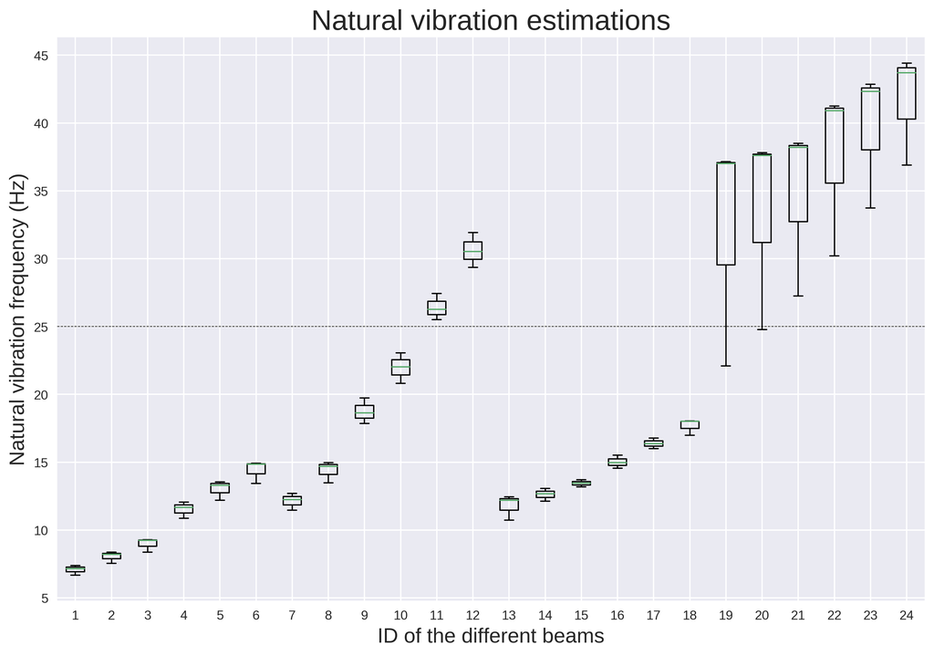

```python
plt.figure(figsize=(12,8), dpi=300)
plt.title("Natural vibration estimations",size=22)
plt.ylabel("Natural vibration frequency (Hz)",size=16)
plt.xlabel("ID of the different beams", size=16)
plt.gca().axhline(y=25, color='k', linewidth=0.5, linestyle="dashed")
# plt.gca().axvline(x=3.5, color='k', linewidth=0.5, linestyle="dashed")

plt.boxplot(values)
plt.show()
```

## Natural vibration frequency vs weight

We would now like to see clearly the different groups of materials used in our analysis. Since the two characteristics that are important to us are minimizing weight and keeping the natural vibration frequency above 25Hz, we use a frequency vs weight plot.

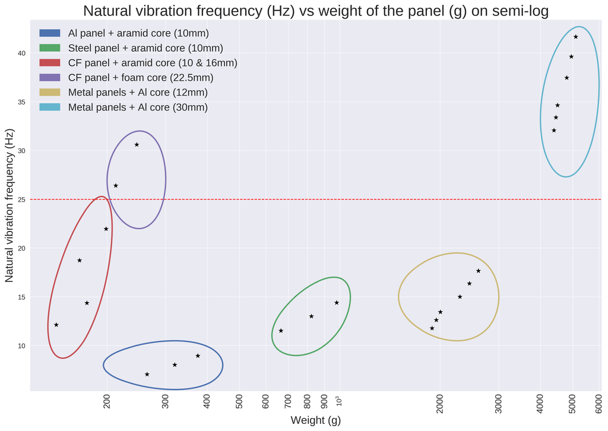

```python
tWeight = [i+5000 for i in weight]

fig = plt.figure(figsize=(15,10), dpi=300)
ax = plt.gca()
ax.scatter(weight, [np.mean(i) for i in values], s=50, color="black", marker="*")

plt.ylabel("Natural vibration frequency (Hz)",size=16)
plt.xlabel("Weight (g)", size=16)
ax.grid(True, which="both", linewidth=0.5)
plt.gca().axhline(y=25, color='r', linewidth=1, linestyle="dashed")


# ax.set_yscale('log')
ax.set_xscale('log')
# ax.set_ylim([0,180])
#foam core carbon fibre panels
e1 = patches.Ellipse((320, 8), 250, 5,
                 angle=0, linewidth=2, fill=False, color="C0")
# #aramid core carbon fibre panels
e2 = patches.Ellipse((850, 13), 450, 7,
                 angle=0.5, linewidth=2, fill=False, color="C1")

# # aluminium core
e3 = patches.Ellipse((170, 17), 75, 13,
                 angle=8, linewidth=2, fill=False, color="C2")
# #aramid core carbon fibre panels
e4 = patches.Ellipse((250, 27),100,10,
                 angle=0.1, linewidth=2, fill=False, color="C3")
# #aluminium core
e5 = patches.Ellipse((2250, 15), 1500, 9,
                 angle=0, linewidth=2, fill=False, color="C4")


e6 = patches.Ellipse((5000, 35), 2000, 15,
                 angle=0.1, linewidth=2, fill=False, color="C5")

ellipseList = [e1,e2,e3,e4,e5,e6]

for i in ellipseList:
    ax.add_patch(i)

patchList = []
for i in range(6):
    patchList.append(patches.Patch(color='C'+str(i), label=titles[i]))

ax.xaxis.set_minor_formatter(FormatStrFormatter("%i"))
ax.yaxis.set_minor_formatter(FormatStrFormatter("%i"))

plt.setp(ax.xaxis.get_minorticklabels(), rotation=90, size=13)
plt.xticks(rotation="vertical")
plt.title("Natural vibration frequency (Hz) vs weight of the panel (g) on semi-log", size=22)
plt.legend(handles=patchList, prop={'size': 15})
plt.show()
```

## Standard deviation of different groups

Since we can only test a total of 6 beams out of 24, we have to choose which one to use. By picking the one with the highest standard deviation for the different estimation methods in each material group, we can find which estimation method was the closest to the truth.

We can then use that estimation method to find the optimal panel dimensions after the testing is done.

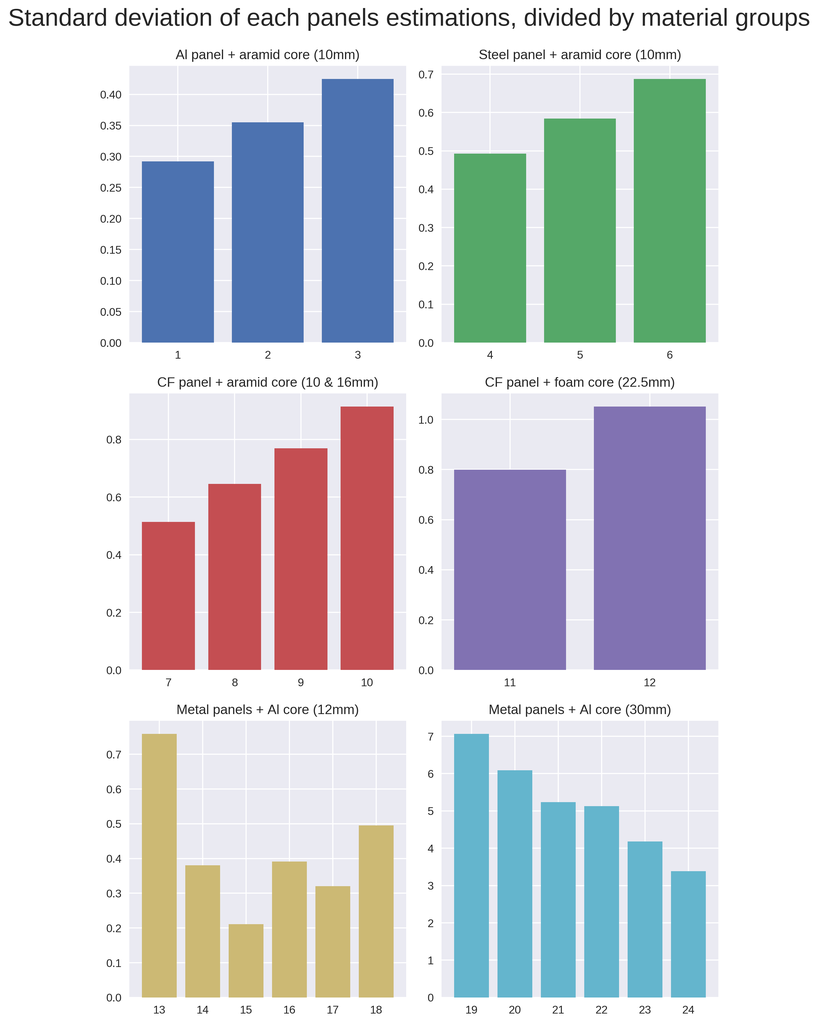

```python
grp1 = (0,2) # Al panel + aramid
grp2 = (3,5) # Steel panel + aramid
grp3 = (6,9) # cf + aramid
grp4 = (10,11) # cf + foam core
grp5 = (12,17) # metal panels + al core 12mm
grp6 = (18, 23) # metal panels + al core 30mm

grpList = [grp1, grp2, grp3, grp4, grp5, grp6]
grpList2 = [grp5,grp6]

f, axs = plt.subplots(3, 2,sharey="none", figsize=(8,13), dpi=300)
axs = axs.ravel()
stdList = []
n=0

for grp in grpList:
    vibSlice=values[grp[0]:grp[1]+1]
    weightSlice = weight[grp[0]:grp[1]+1]
    STD = [np.std(i) for i in vibSlice]
    stdList.append(STD)
    axs[n].bar(range(grp[0], grp[1]+1),STD,color="C"+str(n))
    axs[n].set_xticks(range(grp[0], grp[1]+1))
    axs[n].set_xticklabels([str(i+1) for i in range(grp[0], grp[1]+1)])
    axs[n].set_title(titles[n])
    ratio_default=(axs[n].get_xlim()[1]-axs[n].get_xlim()[0])/(axs[n].get_ylim()[1]-axs[n].get_ylim()[0])
    axs[n].set_aspect(ratio_default)
    n+=1

plt.suptitle("Standard deviation of each panels estimations, divided by material groups", size=22)
plt.tight_layout()
f.subplots_adjust(top=0.93)
plt.show()
```

So the panels that will be tested are **3, 6, 10, 12, 13 & 19.**

- 3 - Al panel (1.2mm) + Aramid core (10mm)
- 6 - Steel panel (1.2mm) + Aramid core(10mm)
- 10 - CF Panel (1mm) + Aramid core (16mm)
- 12 - CF Panel (1mm) + Foam core (22.5mm)
- 13 - Al panel (0.8mm) + Al core (12mm)
- 19 - Al panel (0.8mm) + Al core (30mm)